# Proyecto3

José Prince, Andre Jo y Nelson Escalante

2025-03-26

# Proyecto 3 Análisis Exploratorio

### Enlace a Github

[[https://github.com/Jose-Prince/Proyecto3-Mineria-de-datos]]

## Situación Problemática

### Planteamiento del Problema

En las últimas décadas, la edad a la que las parejas se divorciaron ha cambiado considerablemente. La edad media de divorcio se ha incrementado, y varios estudios sugieren que la presión laboral, la dificultad para equilibrar las responsabilidades familiares y el estrés económico pueden influir en la estabilidad de los matrimonios. Sin embargo, existe la pregunta de si el momento en que las parejas deciden divorciarse está relacionado con su edad y con la dinámica de trabajo que enfrentan.

El comportamiento de las parejas frente al divorcio está condicionado por muchos factores, como el avance de la carrera profesional, las expectativas familiares y las responsabilidades laborales. Los hombres y mujeres que se casan a edades más jóvenes suelen enfrentar mayores desafíos relacionados con la madurez emocional, el establecimiento de una carrera profesional y la formación de una familia. Estos factores pueden influir en la aparición de tensiones y conflictos, que eventualmente podrían desembocar en una separación.

Por otro lado, las parejas que se divorcian a edades más avanzadas podrían enfrentar diferentes retos, como la adaptación a cambios en sus roles laborales, el vacío de los hijos ya adultos o los efectos del envejecimiento. Además, el tipo de ocupación y las horas de trabajo pueden jugar un papel importante en la acumulación de tensiones dentro de la relación, afectando la duración del matrimonio y el momento en que se toma la decisión de divorciarse.

### Pregunta de Investigación:

¿Cómo influye la edad de los cónyuges y su ocupación en el momento en que se produce el divorcio y en la estabilidad matrimonial?

## Problema Científico

En las últimas décadas, los patrones de divorcio han mostrado cambios significativos, con un incremento en la edad promedio de las parejas que deciden separarse. Si bien existen diversos factores que influyen en la disolución matrimonial, la relación entre la edad de los cónyuges, su ocupación y la estabilidad matrimonial sigue siendo un área de investigación relevante y poco comprendida.

La dinámica laboral, las presiones económicas y las expectativas sociales pueden generar tensiones que afectan la convivencia y el bienestar emocional de las parejas. Por un lado, las personas que contraen matrimonio a edades más jóvenes suelen enfrentar desafíos asociados con la inmadurez emocional, la falta de estabilidad financiera y la incertidumbre profesional. Por otro lado, las parejas que deciden separarse a edades más avanzadas pueden verse influidas por otros factores, como el desgaste emocional acumulado, la adaptación a nuevas etapas de la vida o los cambios en sus roles laborales.

Además, el tipo de ocupación desempeñado por cada cónyuge puede influir significativamente en la estabilidad matrimonial. Profesiones con largas jornadas laborales, altos niveles de estrés o falta de conciliación entre la vida personal y profesional pueden incrementar el riesgo de divorcio. A su vez, las diferencias en los ingresos económicos y las percepciones de equidad en las responsabilidades familiares también pueden desencadenar conflictos.

Por lo tanto, resulta fundamental investigar cómo la edad de los cónyuges y su situación laboral influyen en el momento en que se produce el divorcio. Comprender estos factores permitirá no solo identificar los principales determinantes del divorcio en diferentes etapas de la vida, sino también contribuir al desarrollo de políticas públicas y programas de apoyo que promuevan relaciones más estables y saludables.

Este estudio se centrará en explorar la relación entre la edad de los cónyuges, sus ocupaciones y la probabilidad de divorcio, con el objetivo de proporcionar una visión integral sobre las dinámicas matrimoniales contemporáneas.

## Objetivos

### Objetivo General

Analizar la influencia de la edad y las ocupaciones laborales en el momento en que las parejas deciden divorciarse, explorando cómo estas variables afectan la estabilidad matrimonial y la duración de los matrimonios.

### Objetivos Específicos

Investigar la relación entre la edad de los cónyuges y el tiempo de duración del matrimonio, identificando los momentos críticos en los que es más probable que ocurra el divorcio.

Evaluar el impacto de las responsabilidades laborales y la ocupación de los cónyuges en las tensiones dentro del matrimonio, analizando si ciertas ocupaciones o niveles de estrés laboral están correlacionados con una mayor probabilidad de divorcio.

## Descripción de los datos

Variable Categórica DEPREG - Departamento de registro  
Representa el departamento en el cual se registró el evento (1-22)

Variable Categórica MUPREG - Municipio de registro Representa el municipio en el cual se registró el evento ( 0101-2217 )

Variable Categórica MESREG - Mes de registro Representa el mes en el cual se registró el evento (1-12)

Variable Númerica AÑOREG - Año de registro es representado desde (2012-2024)

Variable Ctaegórica MESOCU - Mes de ocurrencia (1-12)

Variable Númerica AÑOOCU - Año ocurrencia (2012-2024)

Variable Categórica DEPOCU - Departamento de Ocurrencia (1-22)

Variable Categórica MUPOCU - Municipio de ocurrencia ( 0101-2217 ) Lugar que ocurrio el divorcio

Variable Númerica EDADHOM - Edad del hombre rango de 1-100 año y 999 como ignorado

Variable Númerica EDADMUJ - Edad de la Mujer rango de 1-100 año 999 como ignorado

Variable Categórica PUEHOM - Pueblo de pertenencia del hombre (1-5), 9 is ignorado Es la etnia que pertenece si es Maya, Garifuna o Xinca entre otros.

Variable Categórica PUEMUJ - Pueblo de pertenencia de la mujer (1-5), 9 is ignorado Es la etnia que pertenece si es Maya, Garifuna o Xinca entre otros.

Variable Categórica NACHOM - Nacionalidad del hombre (argentina, peru, Guatemala, Venezuela etc..) Denotados por números aunque se observa que 9999 representa valor ignorado

Variable Categórica NACMUJ - Nacionalidad de la mujer (argentina, peru, Guatemala, Venezuela etc..) Denotados por números aunque se observa que 9999 representa valor ignorado

Variable Categórica ESCHOM - Escolaridad del hombre rango de 1 a 6 siendo 1 ninguno y 6 postgrado 9 es ignorado

Variable Categórica ESCMUJ - Escolaridad de la mujer rango de 1 a 6 siendo 1 ninguno y 6 postgrado 9 es ignorado

Variable Categórica CIUOHOM - Ocupación (Subgrupos, CIUO-08) del hombre Ocupación (trabajo) denotado por 01-96 del otro lado se pone IGNORADO y en caso no estar especificado se pone NEOG

Variable Categórica CIUOMUJ - Ocupación (Subgrupos, CIUO-08) de la mujer Ocupación (trabajo) denotado por 01-96 del otro lado se pone IGNORADO y en caso no estar especificado se pone NEOG

Tomar nota que hay unas discrepancias con las ocupaciones en la lista de variables ya que hay algunos archivos en EXCEL que utilizaron codigo de 4 digitos y otros de 2 digitos. Por otro lado si no se encuentra de la lista se tomara en cuenta como otra etiqueta 97 No especificado en otro grupo Por otro lado si hay 9999 se tomara como IGNORADO

Se observa tambien que las variables estan denotadas por codigo lo cual se tiene que utilizar excel de definicion de variables para saber la etiqueta.

```
## [1] 19
```

```
## [1] 81826
```

```
##      DEPREG           MUPREG           MESREG           AÑOREG
##  Min.   : 1.000   Min.   : 101.0   Min.   : 1.000   Min.   :2012
##  1st Qu.: 1.000   1st Qu.: 101.0   1st Qu.: 4.000   1st Qu.:2015
##  Median : 6.000   Median : 601.0   Median : 7.000   Median :2019
##  Mean   : 7.815   Mean   : 786.5   Mean   : 6.546   Mean   :2018
##  3rd Qu.:13.000   3rd Qu.:1304.0   3rd Qu.:10.000   3rd Qu.:2022
##  Max.   :22.000   Max.   :2217.0   Max.   :12.000   Max.   :2024
##
##      DIAOCU          MESOCU           AÑOOCU          DEPOCU
##  Min.   : 1.00   Min.   : 1.000   Min.   :2015    Min.   : 1.000
##  1st Qu.: 8.00   1st Qu.: 3.000   1st Qu.:2017    1st Qu.: 1.000
##  Median :16.00   Median : 6.000   Median :2020    Median : 6.000
##  Mean   :15.78   Mean   : 6.305   Mean   :2020    Mean   : 8.025
##  3rd Qu.:23.00   3rd Qu.: 9.000   3rd Qu.:2022    3rd Qu.:13.000
##  Max.   :31.00   Max.   :12.000   Max.   :2023    Max.   :22.000
##                                   NA's   :16274
##      MUPOCU        EDADHOM         EDADMUJ          PUEHOM          PUEMUJ
##  Min.   : 101   Min.   : 15.0   Min.   : 15.0   Min.   :1.000   Min.   :1.000
##  1st Qu.: 102   1st Qu.: 33.0   1st Qu.: 31.0   1st Qu.:4.000   1st Qu.:4.000
##  Median : 613   Median : 54.0   Median : 49.0   Median :9.000   Median :9.000
##  Mean   : 808   Mean   :484.1   Mean   :481.5   Mean   :6.279   Mean   :6.303
##  3rd Qu.:1317   3rd Qu.:999.0   3rd Qu.:999.0   3rd Qu.:9.000   3rd Qu.:9.000
##  Max.   :2217   Max.   :999.0   Max.   :999.0   Max.   :9.000   Max.   :9.000
##
##      NACHOM           NACMUJ           ESCHOM          ESCMUJ
##  Min.   :  10.0   Min.   :  32.0   Min.   :0.000   Min.   :0.00
##  1st Qu.: 320.0   1st Qu.: 320.0   1st Qu.:3.000   1st Qu.:3.00
##  Median : 320.0   Median : 320.0   Median :5.000   Median :4.00
##  Mean   : 361.6   Mean   : 362.5   Mean   :5.659   Mean   :5.62
##  3rd Qu.: 320.0   3rd Qu.: 320.0   3rd Qu.:9.000   3rd Qu.:9.00
##  Max.   :9999.0   Max.   :9999.0   Max.   :9.000   Max.   :9.00
##
##    CIUOHOM            CIUOMUJ
##  Length:81826       Length:81826
##  Class :character   Class :character
##  Mode  :character   Mode  :character
##
##
##
##
```

## Análisis Exploratorio

### Outliers

Analizando las variables numéricas se encontraron varios datos átipicos que no permiten analizar correctamente este dataset. El primero de ellos es que en AÑOOCU habian datos NA y en las variables EDADHOM y EDADMUJ se encontro que algunas edades estaban colocadas como 999 indicando que la edad era desconocida. En este caso este valor se interpreta como NA y se cambio el 999 por la media de cada edad correpondiente a su sexo.

```
## Variable: DIAOCU
## Valores menos frecuentes: 31
##
## Variable: MESOCU
## Valores menos frecuentes: 12
##
## Variable: DEPREG
## Valores menos frecuentes: Sololá
##
## Variable: MUPREG
## Valores menos frecuentes: Concepción, San MArcos la Laguna
##
## Variable: MESREG
## Valores menos frecuentes: 4
##
## Variable: DEPOCU
## Valores menos frecuentes: Sololá
##
## Variable: MUPOCU
## Valores menos frecuentes: San Pablo la Laguna
##
## Variable: PUEHOM
## Valores menos frecuentes: Xinka
##
## Variable: PUEMUJ
## Valores menos frecuentes: Xinka
##
## Variable: NACHOM
## Valores menos frecuentes: Filipinas, Irán
##
## Variable: NACMUJ
## Valores menos frecuentes: Bolivia, Paraguay, Reino Unido
##
## Variable: ESCHOM
## Valores menos frecuentes: Postgrado
##
## Variable: ESCMUJ
## Valores menos frecuentes: Postgrado
##
## Variable: CIUOHOM
## Valores menos frecuentes: Ayudantes de preparación de alimentos
##
## Variable: CIUOMUJ
## Valores menos frecuentes: Agricultores y trabajadores calificados de explotaciones agropecuarias con destino al mercado, Ensambladores, Oficiales y operarios de la metalurgia, la construcción mecánica y afines, Vendedores ambulantes de servicios y afines
```

De esta forma podemos ver los valores menos comunes (valores atípicos) para las variables categoricas, no hay la necesidad de realizar ninguna transformación para los datos. Es importante recalcar que estos datos es importante contrastarlos con el resto de las variables para identificar si realmente son datos átipicos. Este analisis se realizará más adelante en el analisis categorico de las variables.

### Exploración variables númericas

Se tienen las siguientes variables como númericas:

- **AÑOREG** - Año de registro
- **AÑOOCU** - Año de ocurrencia
- **EDADHOM** - Edad del hombre
- **EDADMUJ** - Edad de la mujer

```
##
##  AÑOREG
## Media : 2018.461
## Mediana : 2019
## Moda : 2023
## Rango : 2012 2024
## Varianza : 12.3628
## Desviacion_Estandar : 3.516078
## Minimo : 2012
## Q1 : 2015
## Q2 : 2019
## Q3 : 2022
## Maximo : 2024
##
##  AÑOOCU
## Media : 2019.555
## Mediana : 2020
## Moda : 2023
## Rango : 2015 2023
## Varianza : 6.834192
## Desviacion_Estandar : 2.614229
## Minimo : 2015
## Q1 : 2017
## Q2 : 2020
## Q3 : 2022
## Maximo : 2023
##
##  EDADHOM
## Media : 36.31324
## Mediana : 36.31324
## Moda : 36.31324
## Rango : 15 98
## Varianza : 53.40144
## Desviacion_Estandar : 7.307629
## Minimo : 15
## Q1 : 33
## Q2 : 36.31324
## Q3 : 36.31324
## Maximo : 98
##
##  EDADMUJ
## Media : 33.14645
## Mediana : 33.14645
## Moda : 33.14645
## Rango : 15 81
## Varianza : 44.62304
## Desviacion_Estandar : 6.680048
## Minimo : 15
## Q1 : 31
## Q2 : 33.14645
## Q3 : 33.14645
## Maximo : 81
```

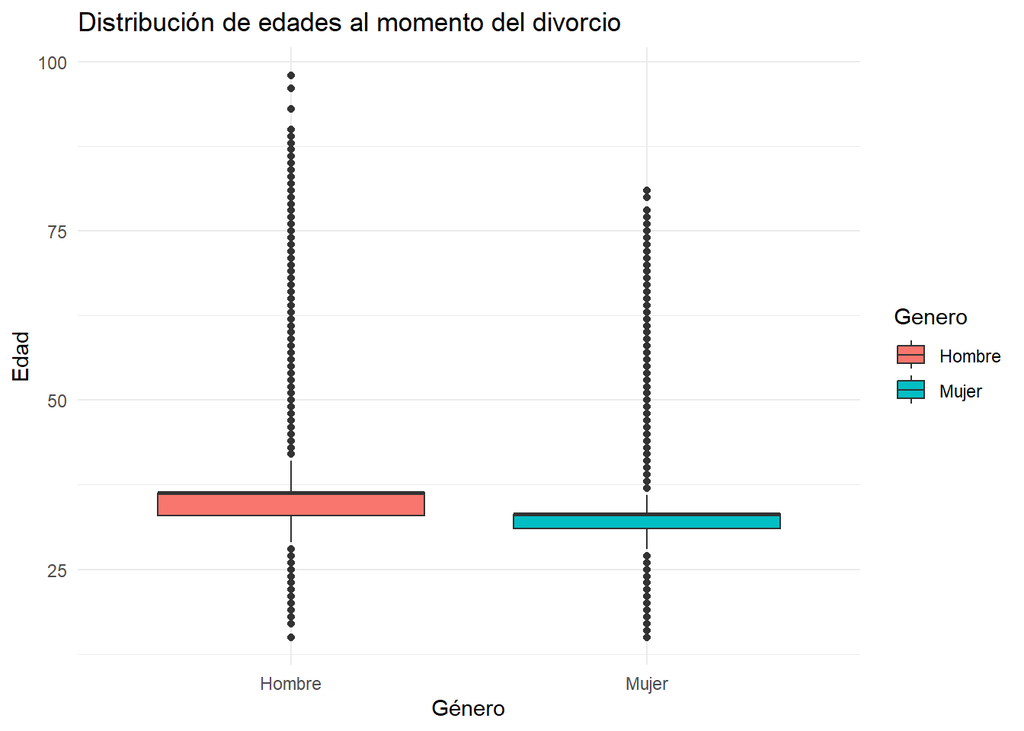

Respecto a las edades (EDADHOM y EDADMUJ), las medias son de aproximadamente 36 y 33 años respectivamente, con una dispersión relativamente baja. Esto sugiere que la mayoría de los registros corresponden a adultos jóvenes (este dato debe ser corroborado debido a la omisión de muchas edades en el dataset). El rango de los hombres es mayor (15 - 98 años) en comparación con el de las mujeres (15 - 81 años), lo que podría reflejar una mayor presencia de hombres de mayor edad en los registros. En general, la distribución de las edades es relativamente homogénea.

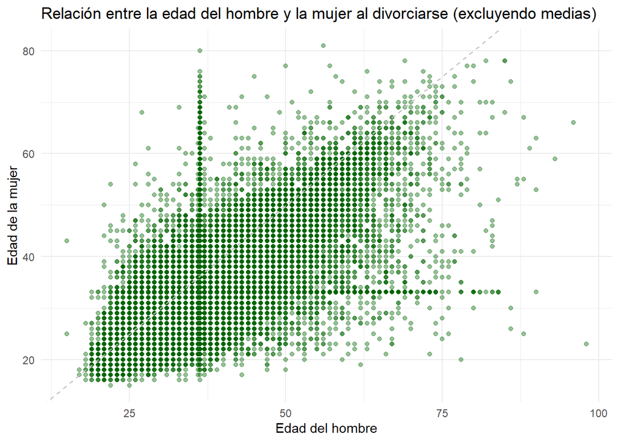

A traves del grafico de dispersion se puede observar con mayor detalle la relacion entre las edades de los hombres y las mujeres divorciados en el conjunto de datos. La linea de identidad nos ayuda a identificar de manera mas visual que las edades de los hombres suelen ser mayores que las de las mujeres. Cabe notar que aproximadamente antes de los 35 años, las edades entre las personas son similares, y luego de este numero las edades de los hombres suele aumenta en relacion a las de las mujeres; esto se puede observar ya que la mayoria de los datos pasados los 35 años se encuentran debajo de la linea de identidad.

### Exploración variables categoricas

Se tienen las siguientes variables como categóricas:

- **DIAOCU** - Día de ocurrencia
- **MESOCU** - Mes de ocurrencia
- **DEPREG** - Departamento de registro
- **MUPREG** - Municipio de registro
- **MESREG** - Mes de registro
- **DEPOCU** - Departamento de ocurrencia
- **MUPOCU** - Municipio de ocurrencia
- **PUEHOM** - Pueblo de pertenencia del hombre
- **PUEMUJ** - Pueblo de pertenencia de la mujer
- **NACHOM** - Nacionalidad del hombre
- **NACMUJ** - Nacionalidad de la mujer
- **ESCHOM** - Escolaridad del hombre
- **ESCMUJ** - Escolaridad de la mujer
- **CIUOHOM** - Ocupación del hombre (según CIUO-08)
- **CIUOMUJ** - Ocupación de la mujer (según CIUO-08)

```
##
##  DEPREG
##         Categoría Frecuencia
## 1    Alta Verapaz       1731
## 2    Baja Verapaz       1418
## 3   Chimaltenango       1801
## 4      Chiquimula       2012
## 5     El Progreso       1485
## 6       Escuintla       3598
## 7       Guatemala      31204
## 8   Huehuetenango       2792
## 9          Izabal       2578
## 10         Jalapa       2029
## 11        Jutiapa       2982
## 12          Petén       2356
```

[output cut: 1010 more lines]

Por otro lado, MUPREG presenta una ayor dispersión con un número más elevado de categorías, algunas con muy pocos registros. La categoría más frecuente (101) tiene 23,848 casos, superando ampliamente a las demás, mientras que muchas otras tienen frecuencias menores a 1,000. Esto sugiere que ciertos valores dominan la distribución mientras que la mayoría son poco representativos. La alta variabilidad en la distribución de frecuencia indica la necesidad de un análisis más profundo para comprender la relevancia de cada categoría y su impacto en el conjunto de datos.

Se estaran utilizando las siguientes variables para realizar un analisis categorico: “DEPREG”, “MUPREG”, “DEPOCU”, “MUPOCU”,“PUEHOM”, “PUEMUJ”, “NACHOM”, “NACMUJ”,“ESCHOM”, “ESCMUJ”, “CIUOHOM”, “CIUOMUJ”

```
##   DEPREG MUPREG DEPOCU MUPOCU PUEHOM PUEMUJ NACHOM NACMUJ ESCHOM ESCMUJ CIUOHOM
## 1      1    101     13   1301      9      9    320    320      1      9    99.0
## 2      1    101      1    101      9      9    840    320      1      9    99.0
## 3     19   1901     19   1901      4      4    320    320      1      9    99.0
## 4      1    101      1    115      9      9    320    320      1      9    99.0
## 5     22   2204     22   2206      4      4    320    320      1      9    99.0
## 6      1    101     22   2201      9      9    320    320      1      9    99.0
##   CIUOMUJ
## 1    23.0
## 2    41.0
## 3    98.0
## 4    98.0
## 5    99.0
## 6    99.0
```

## Cuantos registros de divorcios hay en cada departamento?

```
##          DEPREG Frecuencia
## 1  Alta Verapaz       1731
## 2  Baja Verapaz       1418
## 3 Chimaltenango       1801
## 4    Chiquimula       2012
## 5   El Progreso       1485
## 6     Escuintla       3598
```

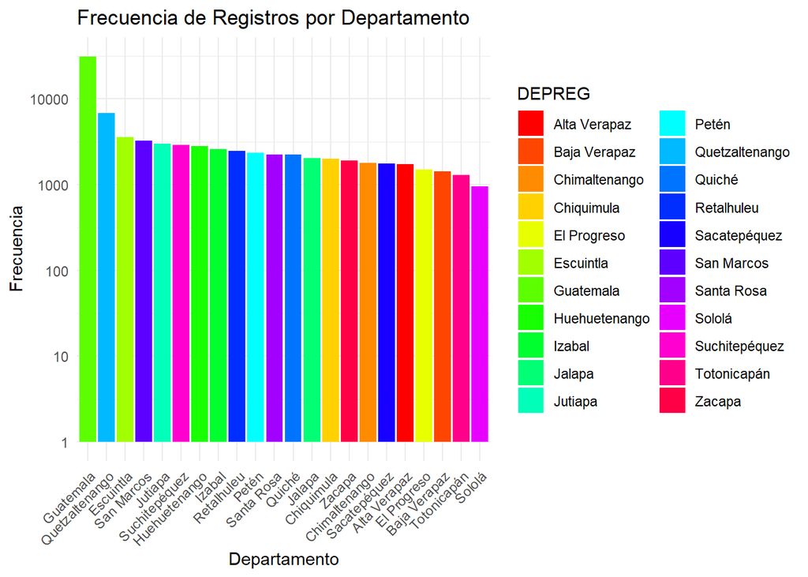

Con estos datos posiblemente podemos realizar un analisis ante la relación entre el pueblo o etnia de las personas divorciadas y el departamento donde se registró el divorcio.

```
##        MUPREG Frecuencia
## 1  Acatenango         17
## 2 Agua Blanca        108
## 3   Aguacatán         39
## 4   Almolonga         48
## 5  Alotenango         81
## 6   Amatitlán       1024
```

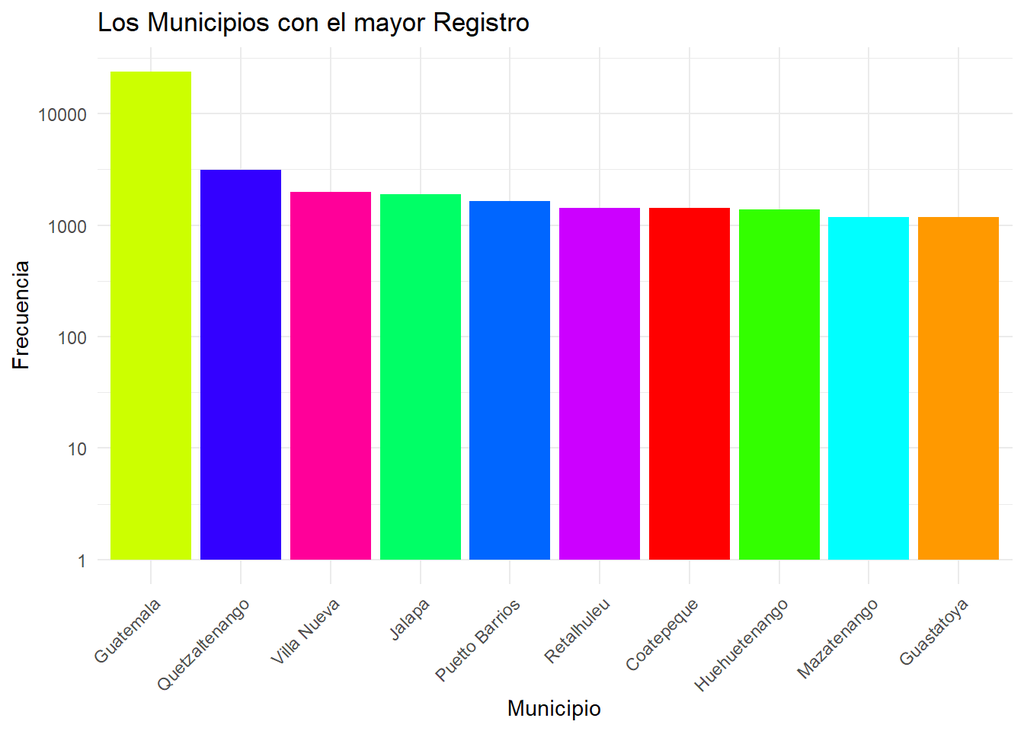

## Que departamento es más frecuente en registrar la ocurrencia del divorcio.

```
##          DEPOCU Frecuencia
## 1  Alta Verapaz       1783
## 2  Baja Verapaz       1587
## 3 Chimaltenango       1761
## 4    Chiquimula       2062
## 5   El Progreso       1454
## 6     Escuintla       3993
```

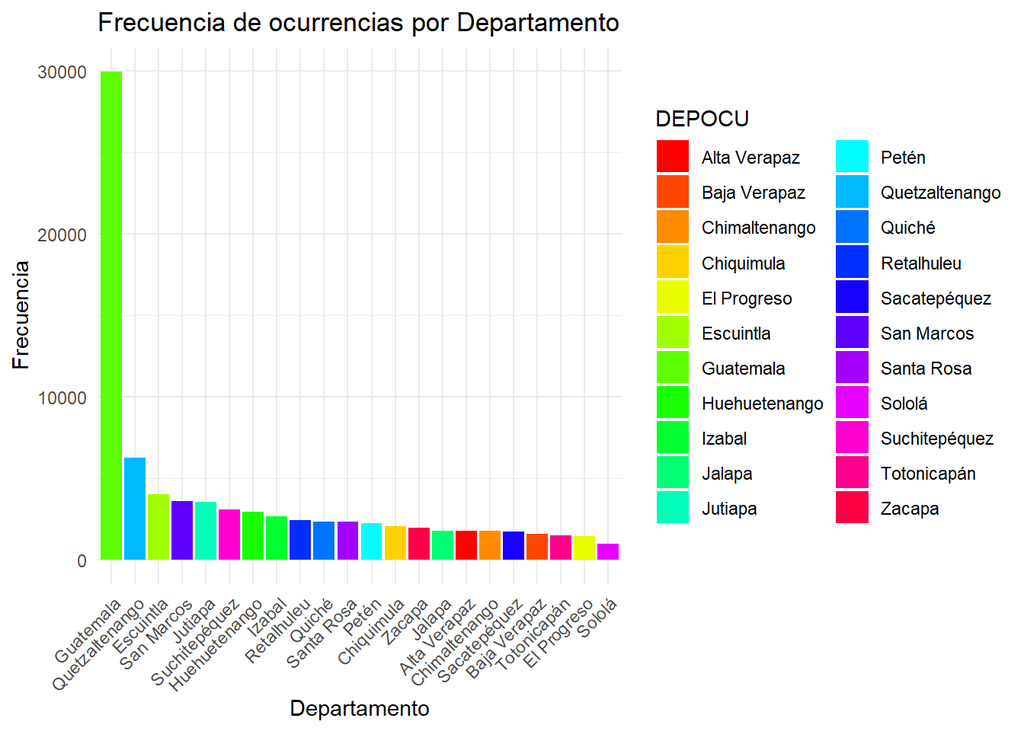

Frecuencia de los municipios con mayor ocurrencia

```
##        MUPOCU Frecuencia
## 1  Acatenango         49
## 2 Agua Blanca        140
## 3   Aguacatán         78
## 4   Almolonga         68
## 5  Alotenango         47
## 6   Amatitlán        981
```

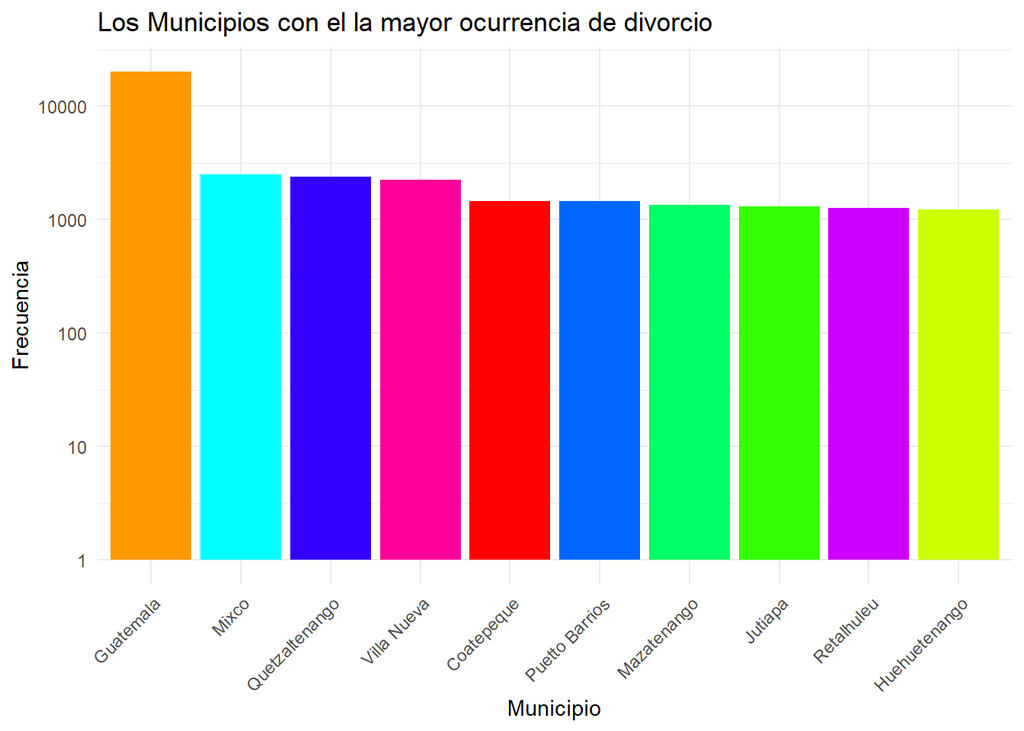

Se confirma también cómo, en el departamento, tienen diferentes datos los registros y las ocurrencias, lo cual indica que son variables diferentes. Sin embargo, lo que más se observa es que el municipio de Guatemala tiene la mayor frecuencia en la ocurrencia de divorcio.

## Frecuencia de etnias registrados por Hombre

```
##             PUEHOM Frecuencia
## 1         Garífuna       1143
## 2         Ignorado      41402
## 3             Maya       6291
## 4 Mestizo / Ladino      32369
## 5             Otro        609
## 6            Xinka         12
```

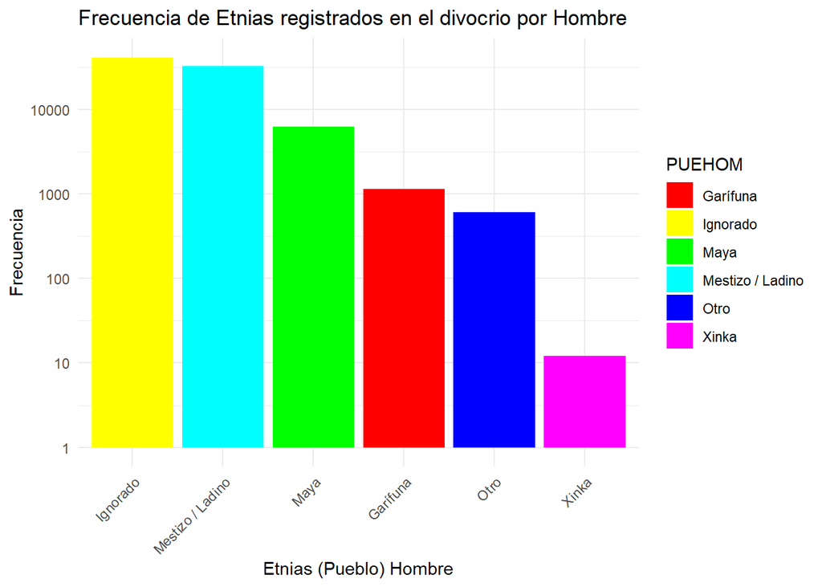

## Mujer

```
##             PUEMUJ Frecuencia
## 1         Garífuna       1171
## 2         Ignorado      41511
## 3             Maya       5820
## 4 Mestizo / Ladino      32621
## 5             Otro        687
## 6            Xinka         16
```

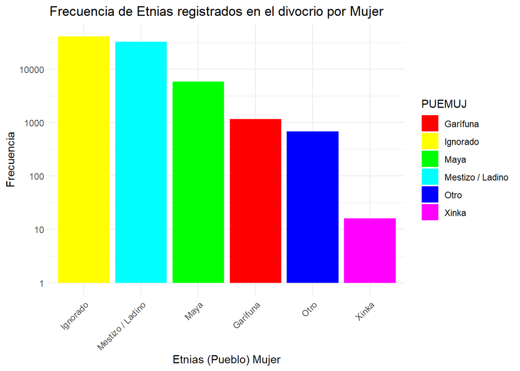

Se observa que la mayor frecuencia es IGNORADO aunque observamos en el segundo puesto que los Mestizos/Ladinos con un total de 32621 registros, luego estan Maya y la menor frecuencia, se encuentra el pueblo Xinka con un total de 16 registros.

## Nacionalidad del Hombre

```
##                                NACHOM Frecuencia
## 1                            Alemania         35
## 2                           Argentina         22
## 3                             Bolivia          8
## 4                               Chile         15
## 5                            Colombia         51
## 6                          Costa Rica         37
## 7                                Cuba         54
## 8                             Ecuador         12
## 9                         El Salvador        176
## 10                     Estados Unidos        327
## 11                          Filipinas          2
## 12                            Francia         13
## 13           G. Bretaña E Irl. Del N.         12
## 14                          Guatemala      80227
## 15             Holanda (Paises Bajos)         10
## 16                           Honduras         64
## 17                           Ignorado        327
## 18                               Irán          2
## 19                             México         77
## 20                          Nicaragua         87
## 21                               Perú         22
## 22 Republica Bolivariana de Venezuela          4
## 23               República Dominicana         11
## 24                             Suecia          3
```

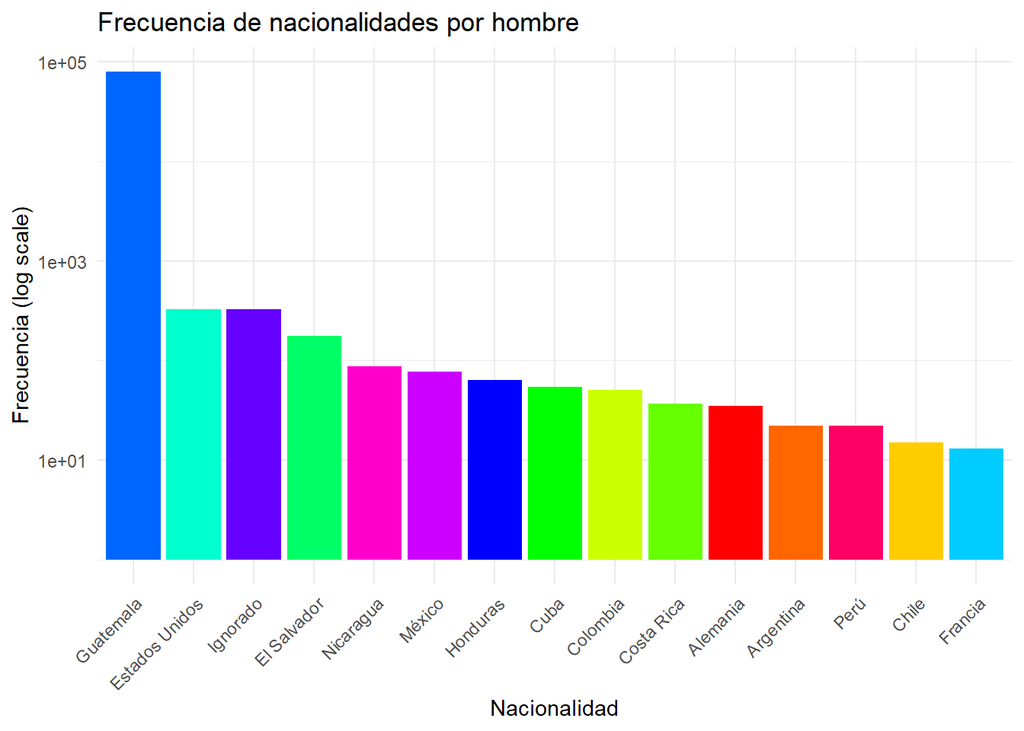

```
##       NACMUJ Frecuencia
## 1   Alemania         21
## 2  Argentina         15
## 3    Bolivia          1
## 4      Chile          6
## 5   Colombia         52
## 6 Costa Rica         33
```

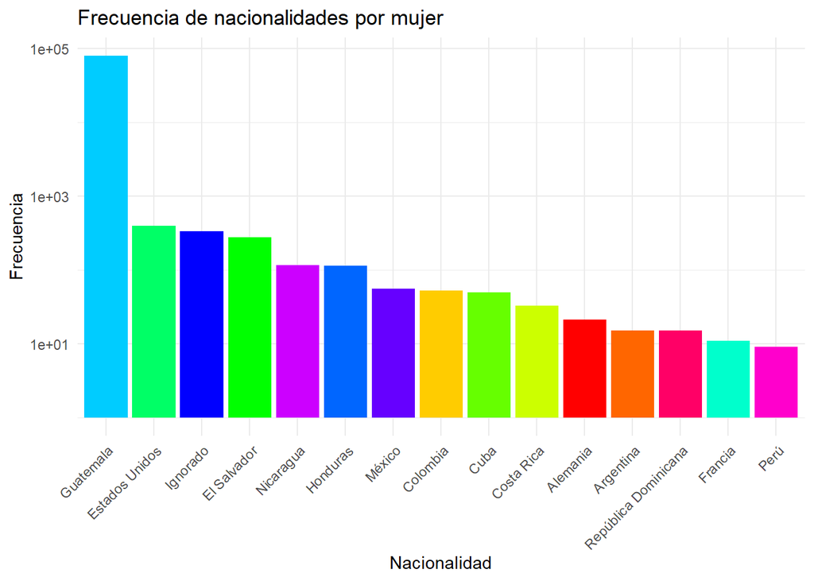

## Exploración de la variable Escolaridad Hombre

```
##          ESCHOM Frecuencia
## 1        Básica       6334
## 2 Diversificado      15951
## 3      Ignorado      36789
## 4       Ninguno       9660
## 5     Postgrado        157
## 6      Primaria       7936
## 7 Universitario       4542
```

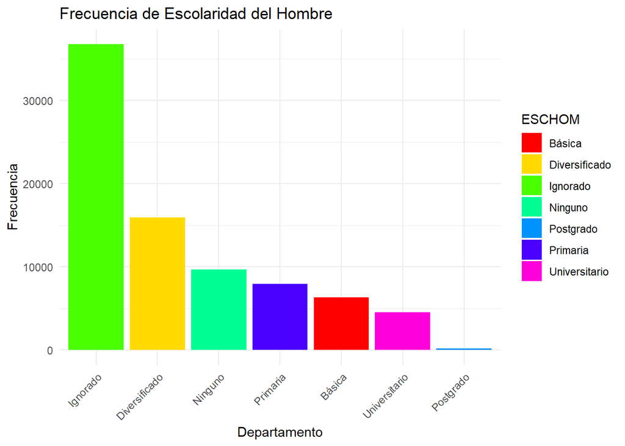

Se observa que la mayor frecuencia corresponde a la variable IGNORADO, lo cual no nos indica si la población está educada o no. Por otro lado, observamos que la variable ‘diversificado’ (15,951) es la más frecuente y tiene cierta significancia. Otro dato importante a resaltar es que la variable ‘ninguno’ es la tercera más frecuente, lo cual podríamos relacionar con la causa del divorcio, si esta está vinculada con la educación.

```
##          ESCMUJ Frecuencia
## 1        Básica       6275
## 2 Diversificado      16452
## 3      Ignorado      36358
## 4       Ninguno      10067
## 5     Postgrado        109
## 6      Primaria       7622
## 7 Universitario       4401
```

[figure not shown]

## Ocupacion Hombres

```
##                                                                                                                     CIUOHOM
## 1                             Agricultores y trabajadores calificados de explotaciones agropecuarias con destino al mercado
## 2                                                                               Artesanos y operarios de las artes gráficas
## 3                                                                                     Ayudantes de preparación de alimentos
## 4                                                          Conductores de vehículos y operadores de equipos pesados móviles
## 5                                                                                  Directores administradores y comerciales
## 6  Directores ejecutivos, personal directivo de la administración pública y miembros del poder ejecutivo y de los cuerpos l
## 7                                                               Empleados contables y encargados del registro de materiales
## 8                                                                                 Empleados de trato directo con el público
## 9                                                                                                             Ensambladores
## 10                                                  Especialistas en organización de la administración pública y de empresa
## 11                                                           Gerentes de hoteles, restaurantes, comercios y otros servicios
## 12                                                                                                                 Ignorado
## 13                                                                                                 Limpiadores y asistentes
## 14                                                                                            No especificado en otro grupo
```

[output cut: 69 more lines]

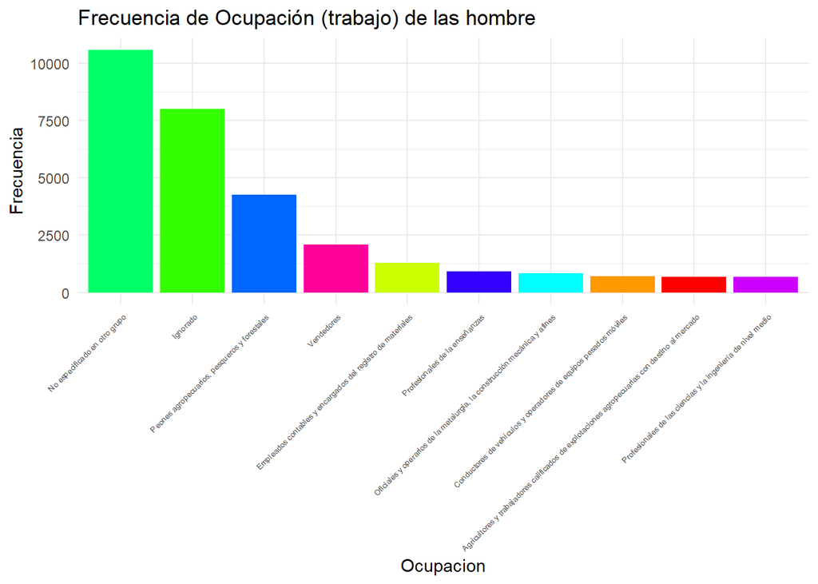

```
##                                                                                                                     CIUOMUJ
## 1                             Agricultores y trabajadores calificados de explotaciones agropecuarias con destino al mercado
## 2                                                                               Artesanos y operarios de las artes gráficas
## 3                                                                                     Ayudantes de preparación de alimentos
## 4                                                          Conductores de vehículos y operadores de equipos pesados móviles
## 5                                                                                  Directores administradores y comerciales
## 6  Directores ejecutivos, personal directivo de la administración pública y miembros del poder ejecutivo y de los cuerpos l
## 7                                                               Empleados contables y encargados del registro de materiales
## 8                                                                                 Empleados de trato directo con el público
## 9                                                                                                             Ensambladores
## 10                                                  Especialistas en organización de la administración pública y de empresa
## 11                                                           Gerentes de hoteles, restaurantes, comercios y otros servicios
## 12                                                                                                                 Ignorado
## 13                                                                                                 Limpiadores y asistentes
## 14                                                                                            No especificado en otro grupo
```

[output cut: 65 more lines]

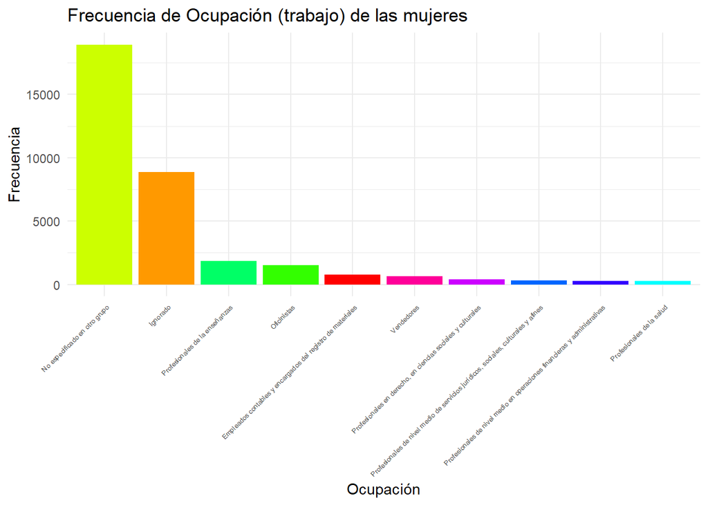

### Tendencia de agrupamiento y número de clusters

```
## [1] "Estadístico de Hopkins: 1"
```

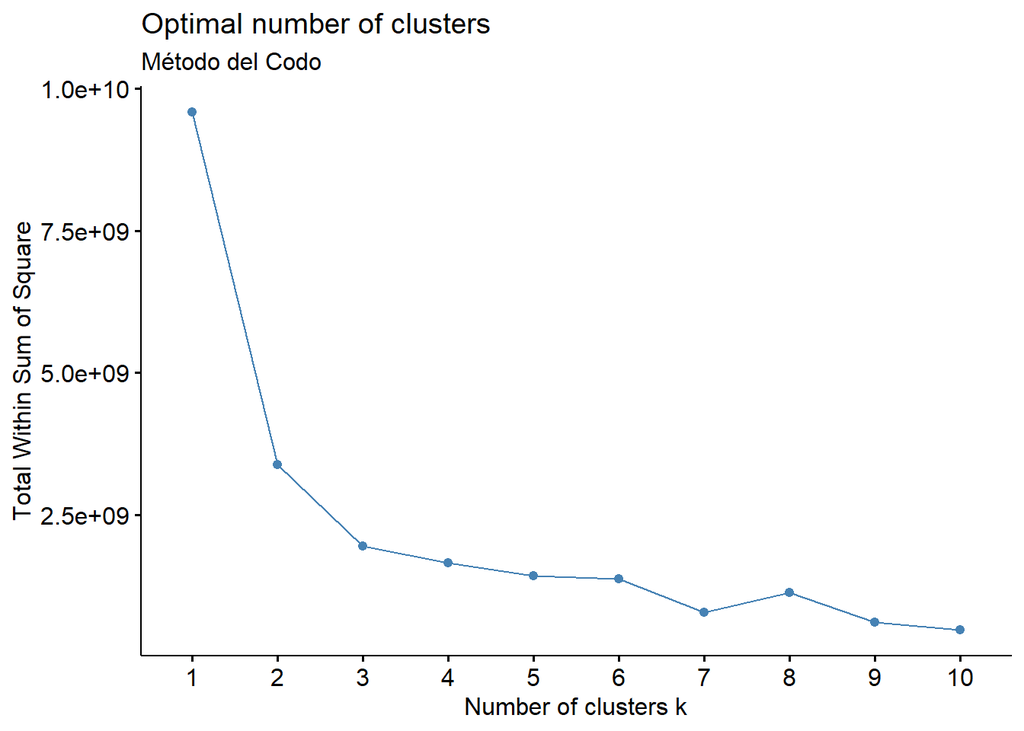

```
##   cluster  size ave.sil.width
## 1       1 14481          0.51
## 2       2 21474          0.62
```

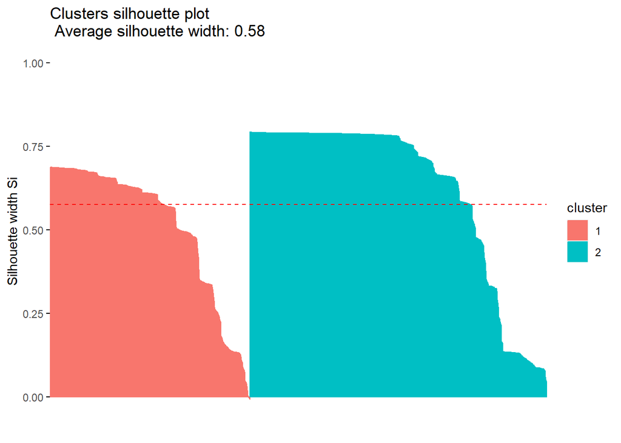

Un valor de 0.58 sugiere que la agrupación es moderadamente buena. Los objetos tienden a estar bien agrupados dentro de sus clústeres, pero hay cierta superposición o cercanía a las fronteras de los clústeres. Esto indica que los clústeres son razonablemente distintos, pero no perfectamente separados.

```
##   Group.1   AÑOREG   AÑOOCU  EDADHOM  EDADMUJ
## 1       1 2020.238 2020.018 35.65141 32.11104
## 2       2 2020.102 2019.922 36.23810 33.45441
```

### Relaciones entre las variables

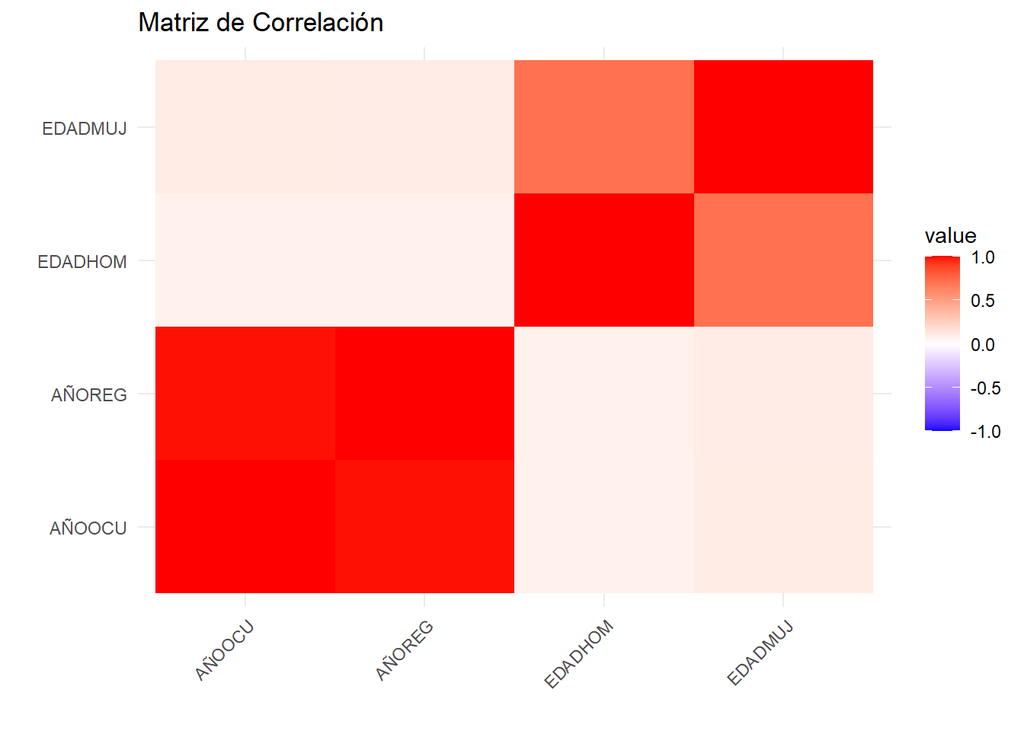

## Hallazgos y conclusiones

### Conclusiones

La fuerte correlación entre las fechas de registro y ocurrencia sugiere una relación temporal en los datos, donde el momento de un evento está estrechamente relacionado con el otro.

La correlación entre las edades de hombres y mujeres podría indicar relaciones o patrones dentro de los eventos registrados relacionados con parejas o individuos dentro de un rango de edad similar.